# Machine learning models part-1

Shorful Alam Akib

2025-04-30

*Linear Regression Lecture*  
Linear Regression is a supervised learning algorithm, meaning we’ll have labeled data and try to predict new labels on unlabeled data. We’ll explore some of the following concepts:

Get our Data  
Exploratory Data Analysis (EDA)  
Clean our Data  
Review of Model Form  
Train and Test Groups  
Linear Regression Model

```r
# Read CSV, note the delimiter (sep)
df <- read.csv('C:/Users/USER/Desktop/!00_days_of_Coding/R/Data Science and Machine Learning Bootcamp with R By Jose Portilla/Machine Learning with R/student-mat.csv',sep=';')
```

Check for missing values

```r
any(is.na(df))
```

```
## [1] FALSE
```

```r
sum(is.na(df))
```

```
## [1] 0
```

Categorical feature  
let’s make sure that categorical variables have a factor set to them.

```r
str(df)
```

```
## 'data.frame':    395 obs. of  33 variables:
##  $ school    : chr  "GP" "GP" "GP" "GP" ...
##  $ sex       : chr  "F" "F" "F" "F" ...
##  $ age       : int  18 17 15 15 16 16 16 17 15 15 ...
##  $ address   : chr  "U" "U" "U" "U" ...
##  $ famsize   : chr  "GT3" "GT3" "LE3" "GT3" ...
##  $ Pstatus   : chr  "A" "T" "T" "T" ...
##  $ Medu      : int  4 1 1 4 3 4 2 4 3 3 ...
##  $ Fedu      : int  4 1 1 2 3 3 2 4 2 4 ...
##  $ Mjob      : chr  "at_home" "at_home" "at_home" "health" ...
##  $ Fjob      : chr  "teacher" "other" "other" "services" ...
##  $ reason    : chr  "course" "course" "other" "home" ...
##  $ guardian  : chr  "mother" "father" "mother" "mother" ...
##  $ traveltime: int  2 1 1 1 1 1 1 2 1 1 ...
##  $ studytime : int  2 2 2 3 2 2 2 2 2 2 ...
```

[output cut: 19 more lines]

```r
df$school <- as.factor(df$school)
df$sex <- as.factor(df$sex)
df$address <- as.factor(df$address)
df$famsize <- as.factor(df$famsize)
df$Pstatus <- as.factor(df$Pstatus)
df$Mjob <- as.factor(df$Mjob)
df$Fjob <- as.factor(df$Fjob)
df$reason <- as.factor(df$reason)
df$guardian <- as.factor(df$guardian)
df$schoolsup <- as.factor(df$schoolsup)
df$famsup <- as.factor(df$famsup)
df$paid <- as.factor(df$paid)
df$activities <- as.factor(df$activities)
df$nursery <- as.factor(df$nursery)
df$higher <- as.factor(df$higher)
df$internet <- as.factor(df$internet)
df$romantic <- as.factor(df$romantic)
```

*Exploratory Data Analysis*

```r
library(ggplot2)
library(ggthemes)
library(dplyr)
```

Correlation and CorrPlots

```r
# Grab only numeric columns
num.cols <- sapply(df, is.numeric)

# Filter to numeric columns for correlation
cor.data <- cor(df[,num.cols])

cor.data
```

```
##                     age         Medu         Fedu   traveltime    studytime
## age         1.000000000 -0.163658419 -0.163438069  0.070640721 -0.004140037
## Medu       -0.163658419  1.000000000  0.623455112 -0.171639305  0.064944137
## Fedu       -0.163438069  0.623455112  1.000000000 -0.158194054 -0.009174639
## traveltime  0.070640721 -0.171639305 -0.158194054  1.000000000 -0.100909119
## studytime  -0.004140037  0.064944137 -0.009174639 -0.100909119  1.000000000
## failures    0.243665377 -0.236679963 -0.250408444  0.092238746 -0.173563031
## famrel      0.053940096 -0.003914458 -0.001369727 -0.016807986  0.039730704
## freetime    0.016434389  0.030890867 -0.012845528 -0.017024944 -0.143198407
## goout       0.126963880  0.064094438  0.043104668  0.028539674 -0.063903675
## Dalc        0.131124605  0.019834099  0.002386429  0.138325309 -0.196019263
## Walc        0.117276052 -0.047123460 -0.012631018  0.134115752 -0.253784731
## health     -0.062187369 -0.046877829  0.014741537  0.007500606 -0.075615863
## absences    0.175230079  0.100284818  0.024472887 -0.012943775 -0.062700175
## G1         -0.064081497  0.205340997  0.190269936 -0.093039992  0.160611915
## G2         -0.143474049  0.215527168  0.164893393 -0.153197963  0.135879999
## G3         -0.161579438  0.217147496  0.152456939 -0.117142053  0.097819690
##               failures       famrel    freetime        goout         Dalc
## age         0.24366538  0.053940096  0.01643439  0.126963880  0.131124605
## Medu       -0.23667996 -0.003914458  0.03089087  0.064094438  0.019834099
## Fedu       -0.25040844 -0.001369727 -0.01284553  0.043104668  0.002386429
## traveltime  0.09223875 -0.016807986 -0.01702494  0.028539674  0.138325309
## studytime  -0.17356303  0.039730704 -0.14319841 -0.063903675 -0.196019263
## failures    1.00000000 -0.044336626  0.09198747  0.124560922  0.136046931
## famrel     -0.04433663  1.000000000  0.15070144  0.064568411 -0.077594357
## freetime    0.09198747  0.150701444  1.00000000  0.285018715  0.209000848
## goout       0.12456092  0.064568411  0.28501871  1.000000000  0.266993848
## Dalc        0.13604693 -0.077594357  0.20900085  0.266993848  1.000000000
## Walc        0.14196203 -0.113397308  0.14782181  0.420385745  0.647544230
## health      0.06582728  0.094055728  0.07573336 -0.009577254  0.077179582
## absences    0.06372583 -0.044354095 -0.05807792  0.044302220  0.111908026
## G1         -0.35471761  0.022168316  0.01261293 -0.149103967 -0.094158792
## G2         -0.35589563 -0.018281347 -0.01377714 -0.162250034 -0.064120183
## G3         -0.36041494  0.051363429  0.01130724 -0.132791474 -0.054660041
##                   Walc       health    absences          G1          G2
## age         0.11727605 -0.062187369  0.17523008 -0.06408150 -0.14347405
## Medu       -0.04712346 -0.046877829  0.10028482  0.20534100  0.21552717
## Fedu       -0.01263102  0.014741537  0.02447289  0.19026994  0.16489339
## traveltime  0.13411575  0.007500606 -0.01294378 -0.09303999 -0.15319796
## studytime  -0.25378473 -0.075615863 -0.06270018  0.16061192  0.13588000
```

[output cut: 13 more lines]

```
## Medu        0.21714750
## Fedu        0.15245694
## traveltime -0.11714205
## studytime   0.09781969
## failures   -0.36041494
## famrel      0.05136343
## freetime    0.01130724
## goout      -0.13279147
## Dalc       -0.05466004
## Walc       -0.05193932
## health     -0.06133460
## absences    0.03424732
## G1          0.80146793
## G2          0.90486799
## G3          1.00000000
```

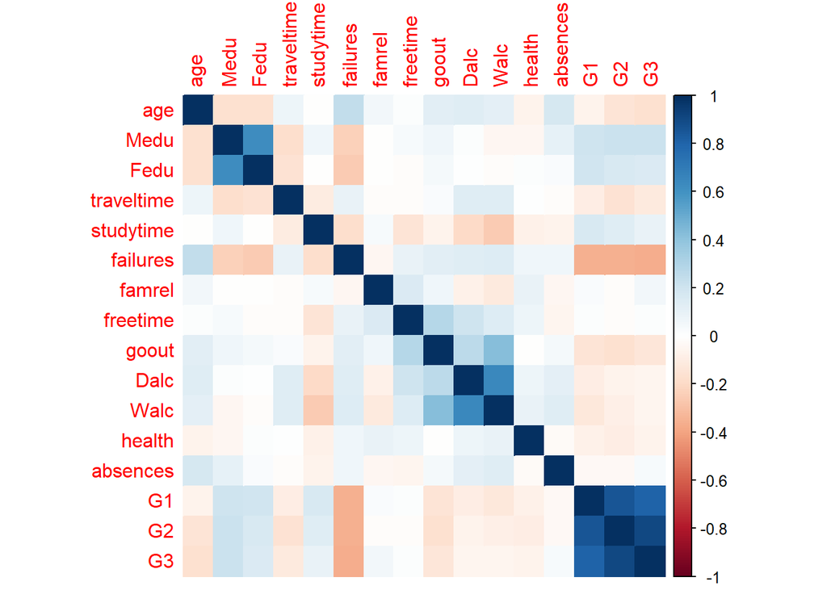

```r
library(corrplot)
library(corrgram)
corrplot(cor.data,method='color')
```

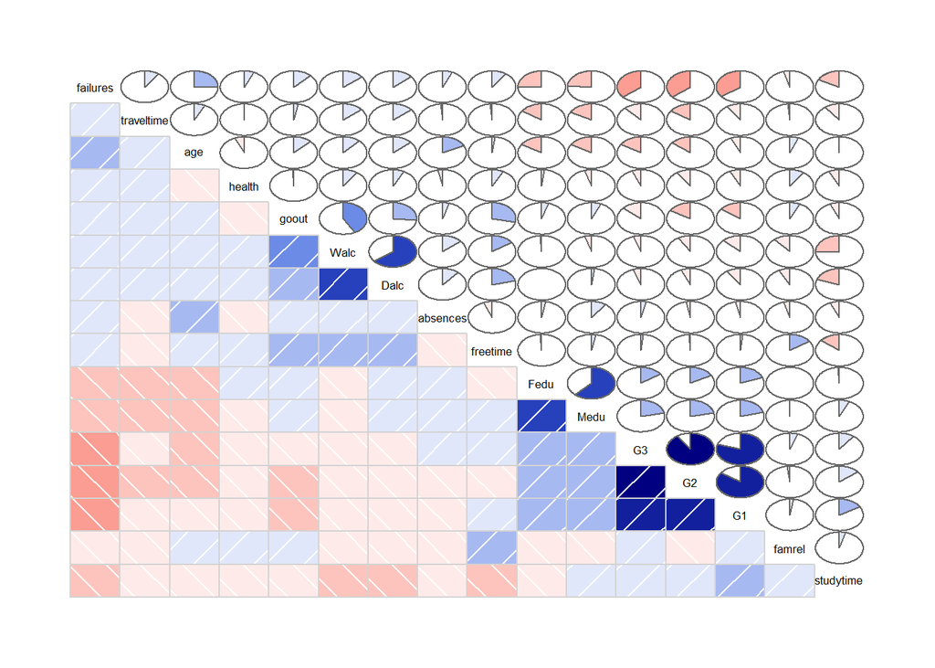

```r
corrgram(df,order=TRUE, lower.panel=panel.shade,
  upper.panel=panel.pie, text.panel=panel.txt)
```

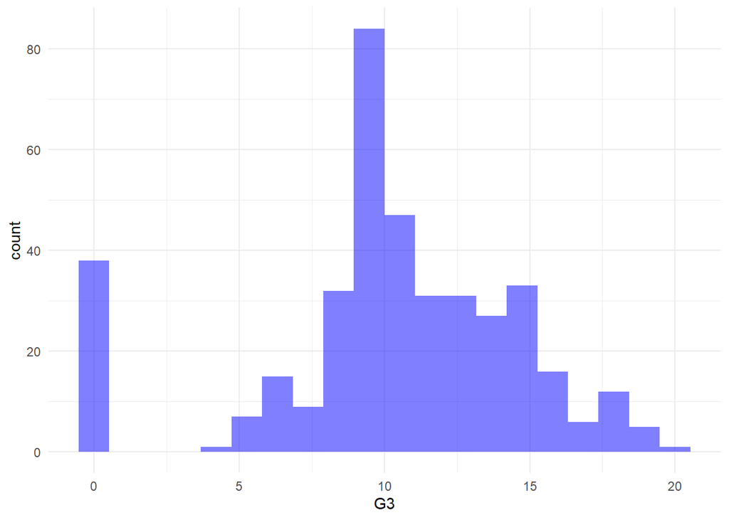

```r
ggplot(df,aes(x=G3)) + geom_histogram(bins=20,alpha=0.5,fill='blue') + theme_minimal()
```

### Building a Model

Train and Test Data  
We’ll need to split our data into a training set and a testing set in order to test our accuracy. We can do this easily using the caTools library:

```r
# Import Library
library(caTools)
# Set a random see so your "random" results are the same as this notebook
set.seed(101)

# Split up the sample, basically randomly assigns a booleans to a new column "sample"
sample <- sample.split(df$age, SplitRatio = 0.70) # SplitRatio = percent of sample==TRUE

# Training Data
train = subset(df, sample == TRUE)

# Testing Data
test = subset(df, sample == FALSE)
```

*Training our Model*  
Let’s train out model on our training data, then ask for a summary of that model:

```r
model <- lm(G3 ~ .,train)
summary(model)
```

```
##
## Call:
## lm(formula = G3 ~ ., data = train)
##
## Residuals:
##     Min      1Q  Median      3Q     Max
## -7.7681 -0.6423  0.2294  1.0691  4.5942
##
## Coefficients:
##                   Estimate Std. Error t value Pr(>|t|)
## (Intercept)      -1.329568   2.474569  -0.537 0.591574
## schoolMS          0.838581   0.470545   1.782 0.076016 .
## sexM              0.034883   0.275586   0.127 0.899382
## age              -0.214994   0.119579  -1.798 0.073472 .
## addressU          0.067190   0.326035   0.206 0.836905
## famsizeLE3       -0.111068   0.283228  -0.392 0.695302
## PstatusT         -0.153653   0.401679  -0.383 0.702417
## Medu              0.279949   0.171111   1.636 0.103164
## Fedu             -0.221275   0.151103  -1.464 0.144422
## Mjobhealth        0.002065   0.610532   0.003 0.997304
## Mjobother         0.509947   0.403195   1.265 0.207209
## Mjobservices      0.475476   0.435332   1.092 0.275857
## Mjobteacher       0.285345   0.550640   0.518 0.604802
## Fjobhealth        0.433172   0.774191   0.560 0.576343
## Fjobother        -0.296792   0.577217  -0.514 0.607611
## Fjobservices     -0.311595   0.593628  -0.525 0.600148
## Fjobteacher      -0.321205   0.712695  -0.451 0.652628
## reasonhome       -0.431435   0.319907  -1.349 0.178755
## reasonother       0.159612   0.454480   0.351 0.725755
## reasonreputation -0.051845   0.317894  -0.163 0.870589
## guardianmother    0.267462   0.311371   0.859 0.391226
## guardianother    -0.157335   0.554872  -0.284 0.777003
## traveltime        0.274301   0.197865   1.386 0.166968
## studytime        -0.140650   0.155149  -0.907 0.365577
## failures         -0.185333   0.211040  -0.878 0.380739
## schoolsupyes      0.562716   0.379303   1.484 0.139268
## famsupyes         0.369402   0.268848   1.374 0.170745
## paidyes           0.060643   0.270971   0.224 0.823107
## activitiesyes    -0.286006   0.247519  -1.155 0.249063
## nurseryyes       -0.426858   0.315064  -1.355 0.176774
## higheryes         0.503353   0.677346   0.743 0.458148
## internetyes      -0.097405   0.331040  -0.294 0.768834
## romanticyes      -0.243837   0.268414  -0.908 0.364577
## famrel            0.494479   0.136663   3.618 0.000363 ***
## freetime         -0.139869   0.138297  -1.011 0.312879
## goout             0.078871   0.128794   0.612 0.540879
## Dalc             -0.248633   0.178366  -1.394 0.164651
## Walc              0.221434   0.139178   1.591 0.112950
## health            0.027495   0.095100   0.289 0.772748
## absences          0.060830   0.017915   3.396 0.000804 ***
## G1                0.162966   0.076956   2.118 0.035255 *
## G2                0.994677   0.066450  14.969  < 2e-16 ***
## ---
## Signif. codes:  0 '***' 0.001 '**' 0.01 '*' 0.05 '.' 0.1 ' ' 1
##
## Residual standard error: 1.868 on 235 degrees of freedom
## Multiple R-squared:  0.8616, Adjusted R-squared:  0.8374
## F-statistic: 35.68 on 41 and 235 DF,  p-value: < 2.2e-16
```

*Visualize our Model*  
We can visualize our linear regression model by plotting out the residuals, the residuals are basically a measure of how off we are for each point in the plot versus our model (the error).

```r
# Grab residuals
res <- residuals(model)

# Convert to DataFrame for gglpot
res <- as.data.frame(res)

head(res)
```

```
##           res
## 1   0.9678451
## 5   1.1829980
## 6  -1.4096050
## 7   0.1125706
## 9   0.3814670
## 10  0.3221204
```

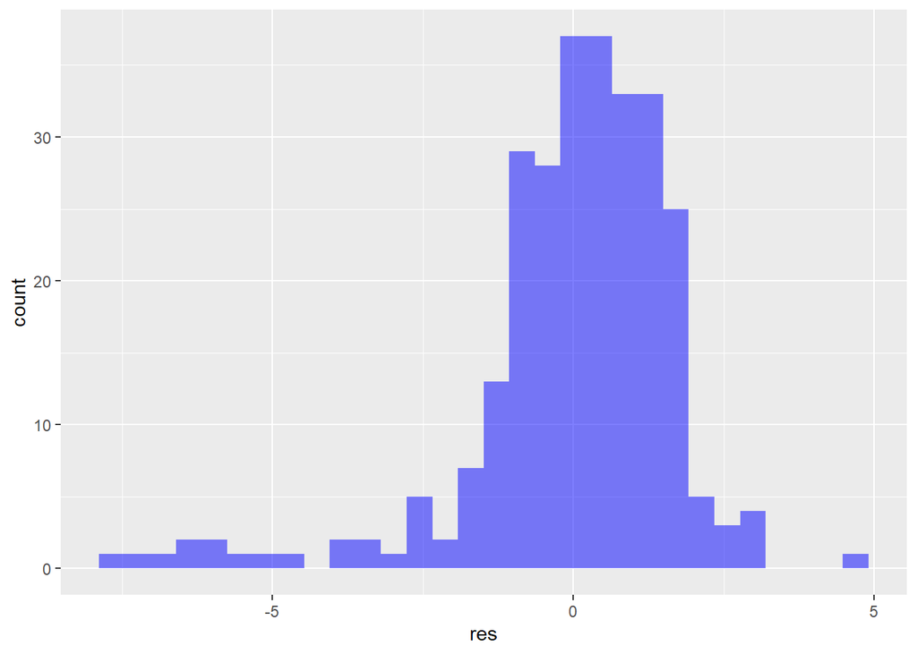

```r
# Histogram of residuals
ggplot(res,aes(res)) +  geom_histogram(fill='blue',alpha=0.5)
```

Plot model

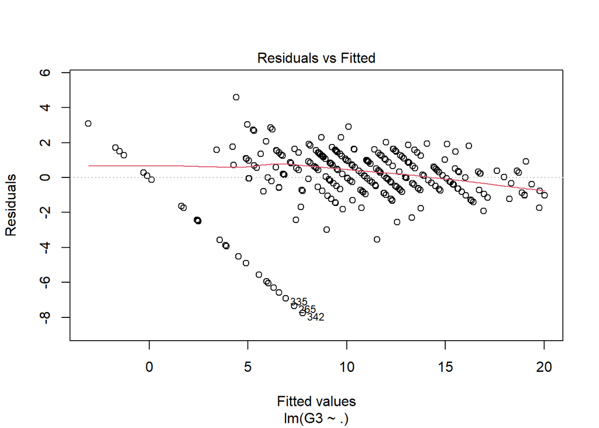

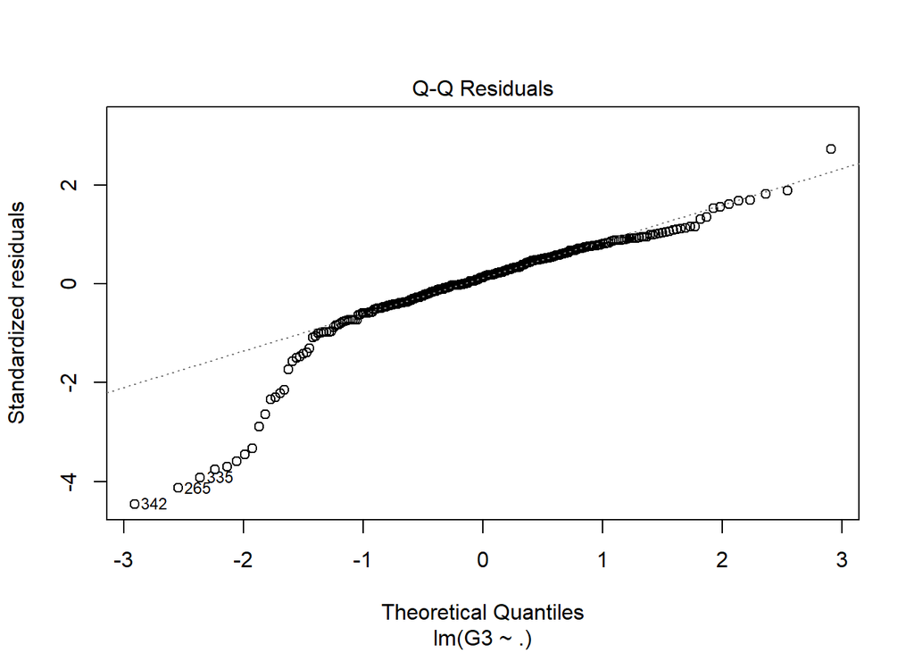

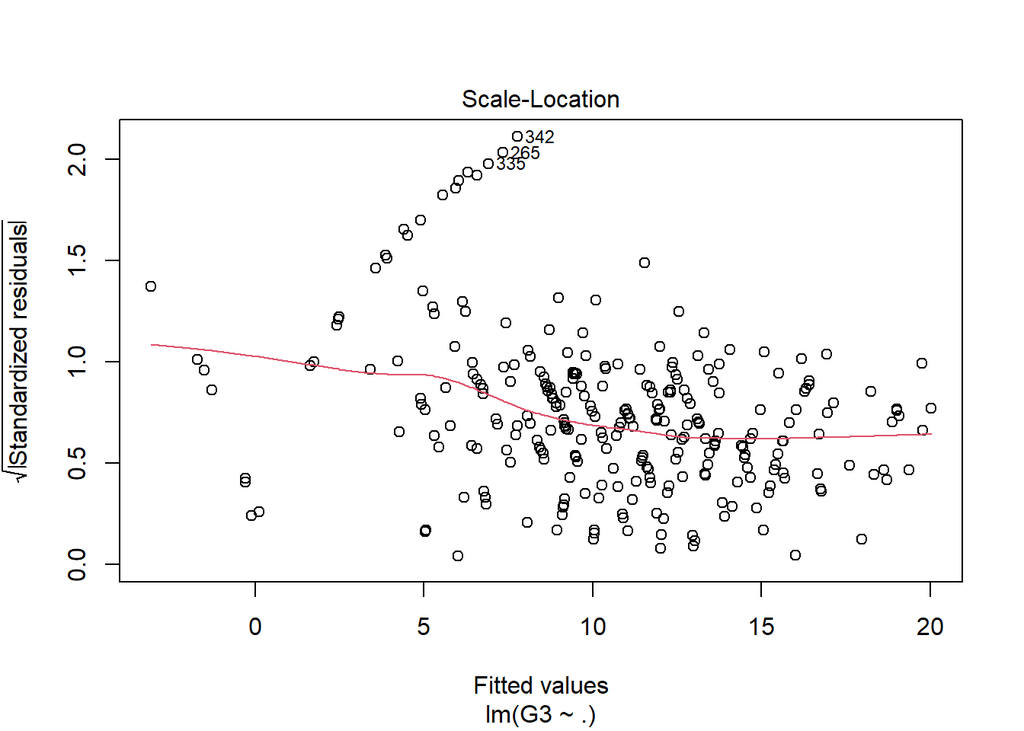

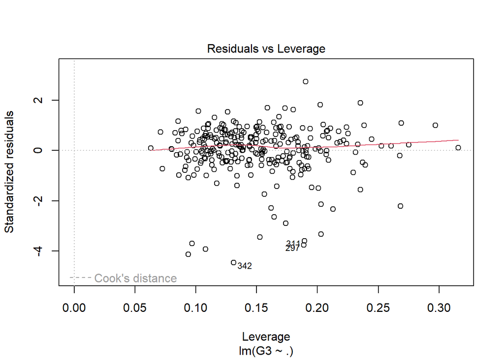

```r
plot(model)
```

*Predictions*  
Let’s test our model by predicting on our testing set:

```r
G3.predictions <- predict(model,test)
results <- cbind(G3.predictions,test$G3)
colnames(results) <- c('pred','real')
results <- as.data.frame(results)
mse <- mean((results$real-results$pred)^2)
print(mse)
```

```
## [1] 4.474506
```

```r
mse^0.5
```

```
## [1] 2.115303
```

```r
SSE = sum((results$pred - results$real)^2)
SST = sum( (mean(df$G3) - results$real)^2)

R2 = 1 - SSE/SST
R2
```

```
## [1] 0.7747253
```

### Logistic Regression Model

```r
df.train <- read.csv('C:/Users/USER/Desktop/!00_days_of_Coding/R/Data Science and Machine Learning Bootcamp with R By Jose Portilla/Machine Learning with R/titanic_train.csv')
```

*Exploratory Data Analysis (EDA)*  
Let’s explore how much missing data we have, we can use the Amelia pacakge for this.

```r
library(Amelia)
```

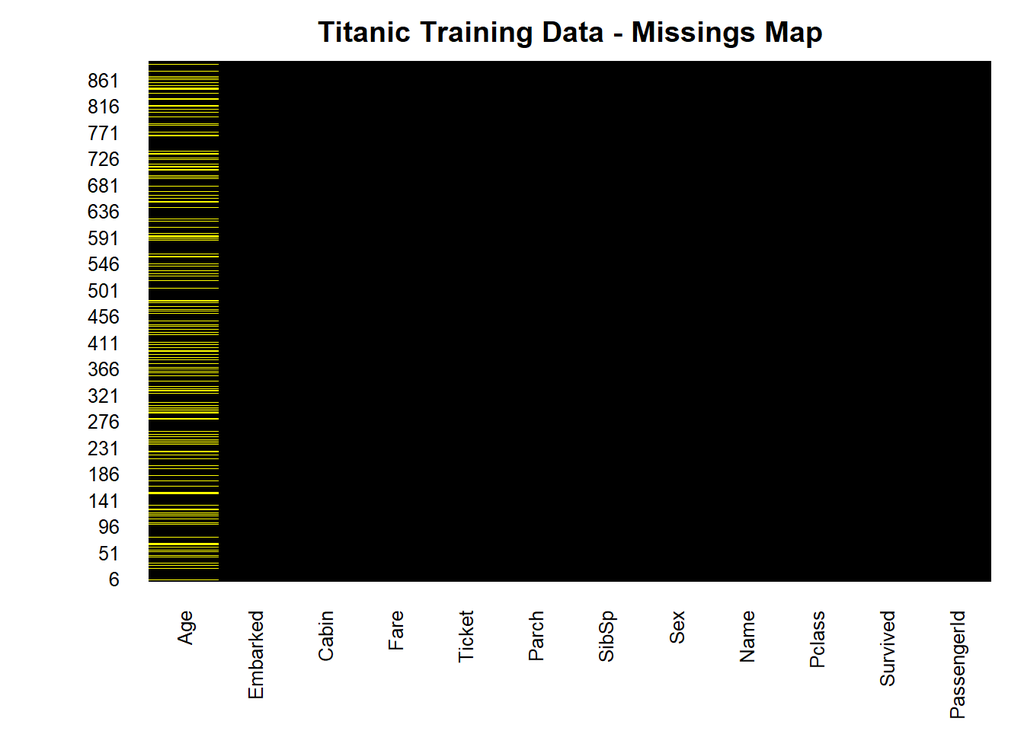

```r
missmap(df.train, main="Titanic Training Data - Missings Map",
        col=c("yellow", "black"), legend=FALSE)
```

*Data Visualization with ggplot2*

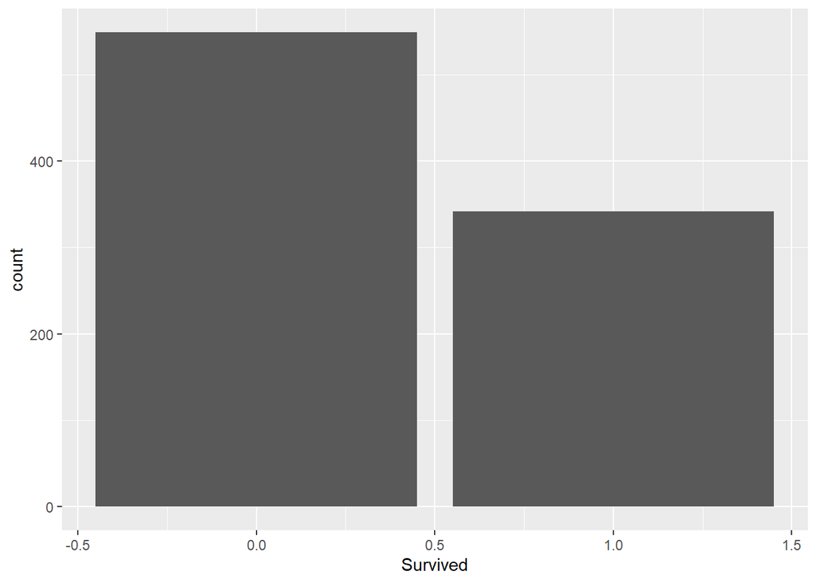

```r
library(ggplot2)
ggplot(df.train,aes(Survived)) + geom_bar()
```

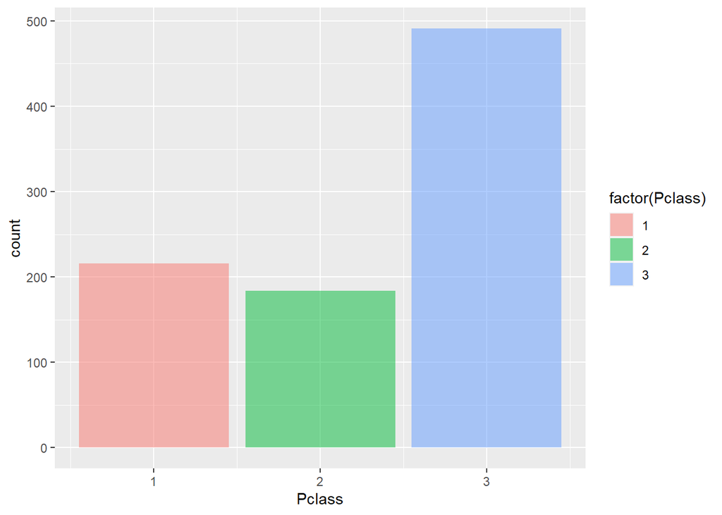

```r
ggplot(df.train,aes(Pclass)) + geom_bar(aes(fill=factor(Pclass)),alpha=0.5)
```

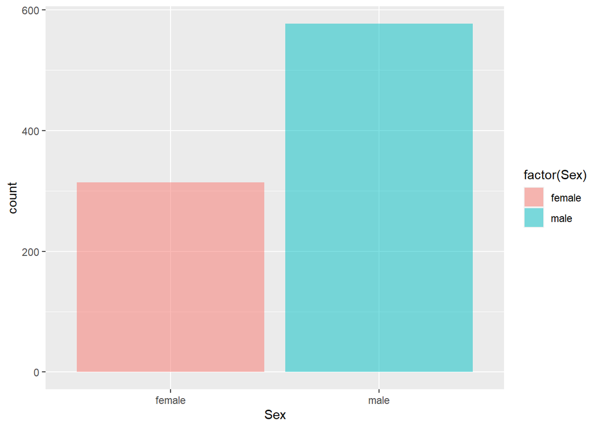

```r
ggplot(df.train,aes(Sex)) + geom_bar(aes(fill=factor(Sex)),alpha=0.5)
```

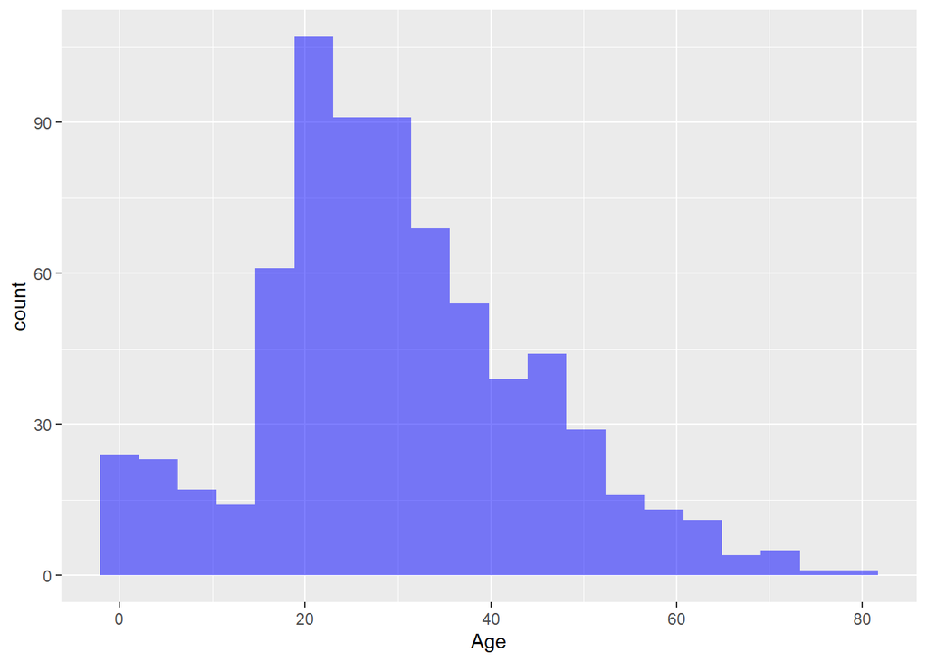

```r
ggplot(df.train,aes(Age)) + geom_histogram(fill='blue',bins=20,alpha=0.5)
```

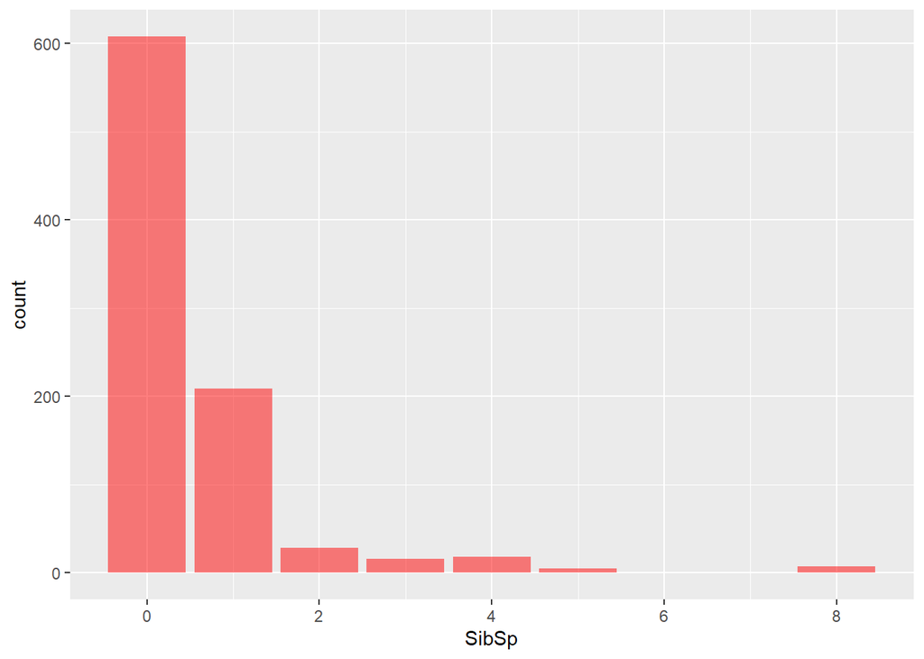

```r
ggplot(df.train,aes(SibSp)) + geom_bar(fill='red',alpha=0.5)
```

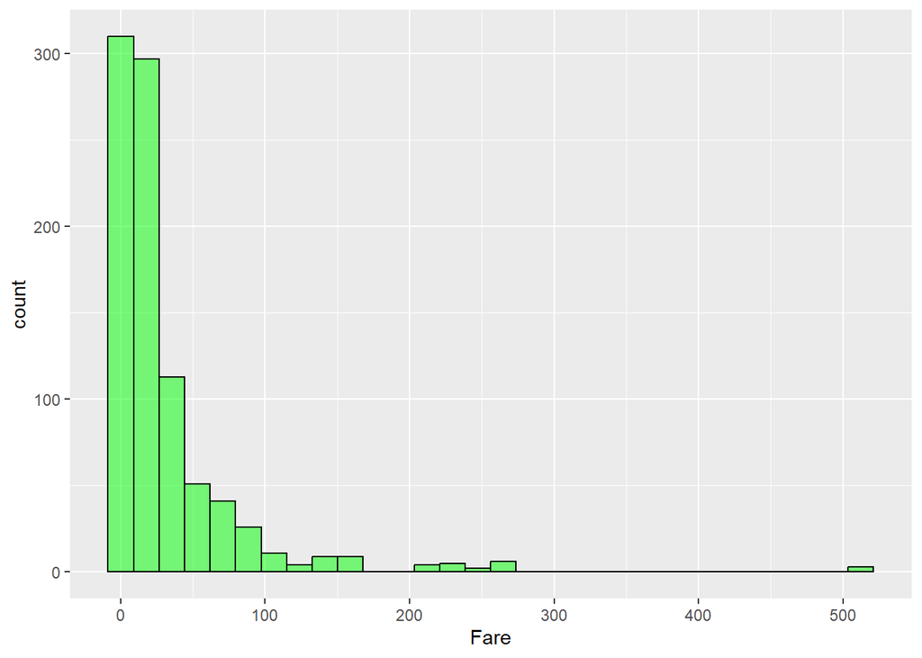

```r
ggplot(df.train,aes(Fare)) + geom_histogram(fill='green',color='black',alpha=0.5)
```

*Data Cleaning*  
We want to fill in missing age data instead of just dropping the missing age data rows. One way to do this is by filling in the mean age of all the passengers (imputation).

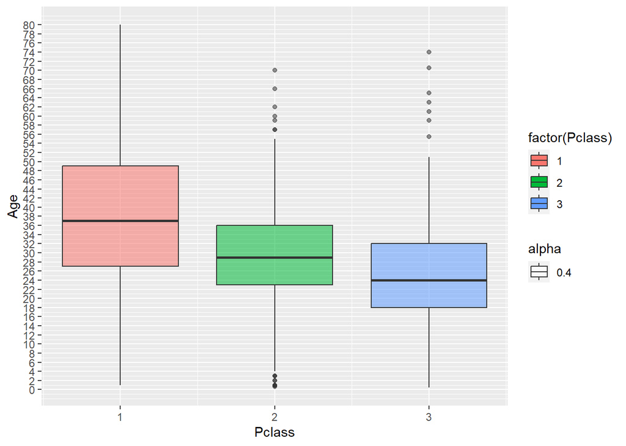

```r
pl <- ggplot(df.train,aes(Pclass,Age)) + geom_boxplot(aes(group=Pclass,fill=factor(Pclass),alpha=0.4))
pl + scale_y_continuous(breaks = seq(min(0), max(80), by = 2))
```

We can see the wealthier passengers in the higher classes tend to be older, which makes sense. We’ll use these average age values to impute based on Pclass for Age.

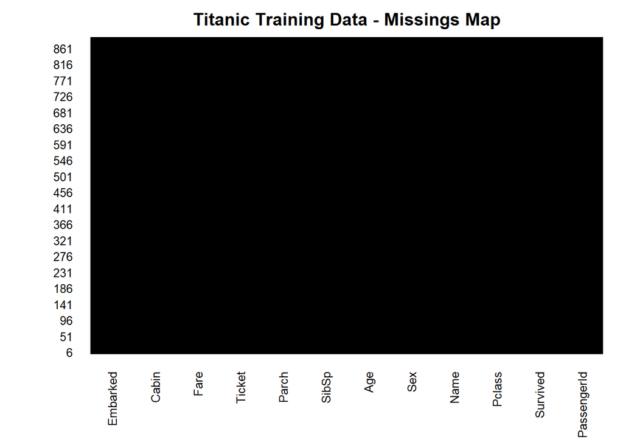

```r
impute_age <- function(age,class){
    out <- age
    for (i in 1:length(age)){

        if (is.na(age[i])){

            if (class[i] == 1){
                out[i] <- 37

            }else if (class[i] == 2){
                out[i] <- 29

            }else{
                out[i] <- 24
            }
        }else{
            out[i]<-age[i]
        }
    }
    return(out)
}
fixed.ages <- impute_age(df.train$Age,df.train$Pclass)
df.train$Age <- fixed.ages
missmap(df.train, main="Titanic Training Data - Missings Map",
        col=c("yellow", "black"), legend=FALSE)
```

### Building a Logistic Regression Model  
Now it is time to build our model! Let’s begin by doing a final “clean-up” of our data by removing the features we won’t be using and making sure that the features are of the correct data type.

```r
df.train <- select(df.train,-PassengerId,-Name,-Ticket,-Cabin)
str(df.train)
```

```
## 'data.frame':    891 obs. of  8 variables:
##  $ Survived: int  0 1 1 1 0 0 0 0 1 1 ...
##  $ Pclass  : int  3 1 3 1 3 3 1 3 3 2 ...
##  $ Sex     : chr  "male" "female" "female" "female" ...
##  $ Age     : num  22 38 26 35 35 24 54 2 27 14 ...
##  $ SibSp   : int  1 1 0 1 0 0 0 3 0 1 ...
##  $ Parch   : int  0 0 0 0 0 0 0 1 2 0 ...
##  $ Fare    : num  7.25 71.28 7.92 53.1 8.05 ...
##  $ Embarked: chr  "S" "C" "S" "S" ...
```

```r
df.train$Survived <- as.factor(df.train$Survived)
df.train$Pclass <- as.factor(df.train$Pclass)
df.train$Parch <- as.factor(df.train$Parch)
df.train$SibSp <- as.factor(df.train$SibSp)
df.train$Sex <- as.factor(df.train$Sex)
df.train$Embarked <- as.factor(df.train$Embarked)
```

#### Train the Model

```r
log.model <- glm(formula=Survived ~ . , family = binomial(link='logit'),data = df.train)
summary(log.model)
```

```
##
## Call:
## glm(formula = Survived ~ ., family = binomial(link = "logit"),
##     data = df.train)
##
## Coefficients:
##               Estimate Std. Error z value Pr(>|z|)
## (Intercept)  1.845e+01  1.660e+03   0.011 0.991134
## Pclass2     -1.079e+00  3.092e-01  -3.490 0.000484 ***
## Pclass3     -2.191e+00  3.161e-01  -6.930 4.20e-12 ***
## Sexmale     -2.677e+00  2.040e-01 -13.123  < 2e-16 ***
## Age         -3.971e-02  8.758e-03  -4.534 5.79e-06 ***
## SibSp1       8.135e-02  2.245e-01   0.362 0.717133
## SibSp2      -2.897e-01  5.368e-01  -0.540 0.589361
## SibSp3      -2.241e+00  7.202e-01  -3.111 0.001862 **
## SibSp4      -1.675e+00  7.620e-01  -2.198 0.027954 *
## SibSp5      -1.595e+01  9.588e+02  -0.017 0.986731
## SibSp8      -1.607e+01  7.578e+02  -0.021 0.983077
## Parch1       3.741e-01  2.895e-01   1.292 0.196213
## Parch2       3.862e-02  3.824e-01   0.101 0.919560
## Parch3       3.655e-01  1.056e+00   0.346 0.729318
## Parch4      -1.586e+01  1.055e+03  -0.015 0.988007
## Parch5      -1.152e+00  1.172e+00  -0.983 0.325771
## Parch6      -1.643e+01  2.400e+03  -0.007 0.994536
## Fare         2.109e-03  2.490e-03   0.847 0.397036
## EmbarkedC   -1.458e+01  1.660e+03  -0.009 0.992995
## EmbarkedQ   -1.456e+01  1.660e+03  -0.009 0.993001
## EmbarkedS   -1.486e+01  1.660e+03  -0.009 0.992857
## ---
## Signif. codes:  0 '***' 0.001 '**' 0.01 '*' 0.05 '.' 0.1 ' ' 1
##
## (Dispersion parameter for binomial family taken to be 1)
##
##     Null deviance: 1186.66  on 890  degrees of freedom
## Residual deviance:  763.41  on 870  degrees of freedom
## AIC: 805.41
##
## Number of Fisher Scoring iterations: 15
```

*Predicting using Test Cases*  
Let’s make a test set out of our training set, retrain on the smaller version of our training set and check it against the test subset.

```r
library(caTools)
set.seed(101)

split = sample.split(df.train$Survived, SplitRatio = 0.70)

final.train = subset(df.train, split == TRUE)
final.test = subset(df.train, split == FALSE)
final.log.model <- glm(formula=Survived ~ . , family = binomial(link='logit'),data = final.train)
summary(final.log.model)
```

```
##
## Call:
## glm(formula = Survived ~ ., family = binomial(link = "logit"),
##     data = final.train)
##
## Coefficients:
##               Estimate Std. Error z value Pr(>|z|)
## (Intercept)  1.777e+01  2.400e+03   0.007 0.994091
## Pclass2     -1.230e+00  3.814e-01  -3.225 0.001261 **
## Pclass3     -2.160e+00  3.841e-01  -5.624 1.87e-08 ***
## Sexmale     -2.660e+00  2.467e-01 -10.782  < 2e-16 ***
## Age         -3.831e-02  1.034e-02  -3.705 0.000212 ***
## SibSp1      -2.114e-02  2.755e-01  -0.077 0.938836
## SibSp2      -4.000e-01  6.463e-01  -0.619 0.536028
## SibSp3      -2.324e+00  8.994e-01  -2.584 0.009765 **
## SibSp4      -1.196e+00  8.302e-01  -1.440 0.149839
## SibSp5      -1.603e+01  9.592e+02  -0.017 0.986666
## SibSp8      -1.633e+01  1.004e+03  -0.016 0.987019
## Parch1       7.290e-01  3.545e-01   2.056 0.039771 *
## Parch2       1.406e-01  4.504e-01   0.312 0.754892
## Parch3       7.919e-01  1.229e+00   0.645 0.519226
## Parch4      -1.498e+01  1.552e+03  -0.010 0.992300
## Parch5      -9.772e-03  1.378e+00  -0.007 0.994343
## Parch6      -1.635e+01  2.400e+03  -0.007 0.994563
## Fare         3.128e-03  3.091e-03   1.012 0.311605
## EmbarkedC   -1.398e+01  2.400e+03  -0.006 0.995353
## EmbarkedQ   -1.387e+01  2.400e+03  -0.006 0.995386
## EmbarkedS   -1.431e+01  2.400e+03  -0.006 0.995243
## ---
## Signif. codes:  0 '***' 0.001 '**' 0.01 '*' 0.05 '.' 0.1 ' ' 1
##
## (Dispersion parameter for binomial family taken to be 1)
##
##     Null deviance: 829.60  on 622  degrees of freedom
## Residual deviance: 530.63  on 602  degrees of freedom
## AIC: 572.63
##
## Number of Fisher Scoring iterations: 15
```

Now let’s check our prediction accuracy!

```r
fitted.probabilities <- predict(final.log.model,newdata=final.test,type='response')
fitted.results <- ifelse(fitted.probabilities > 0.5,1,0)
misClasificError <- mean(fitted.results != final.test$Survived)
print(paste('Accuracy',1-misClasificError))
```

```
## [1] "Accuracy 0.798507462686567"
```

Looks like we were able to achieve around 80% accuracy, where as random guessing would have just been 50% accuracy. Let’s see the confusion matrix:

```r
table(final.test$Survived, fitted.probabilities > 0.5)
```

```
##
##     FALSE TRUE
##   0   140   25
##   1    29   74
```